# Tweedie GLM Model

Joseph Rickert

Friday, September 19, 2014

### Background

The Tweedie family of distributions provide flexible models for estimation. The power parameter var.power determines the shape of the distribution var.power = 0 => Tweedie is a normal distribution 1 => Tweedie is Poisson 2 => Tweedie is Gamma 3 => Tweedie is inverse Gaussian. between 1 and 2 => Tweedie is a compound Poisson distribution and is appropriate for positive data that also contains exact zeros, for example, insurance claims data, rainfall data, or fish-catch data. > 2 is appropriate for positive data

The data for our example is subsample from the 5% sample of the U.S. 2000 census. We will consider the annual cost of property insurance for heads of household ages 21 through 89, and its relationship to age, sex, and region. The variable “perwt” represents the probability weight for that observation.

### Get the Data

```r
dataPath = "C:/DATA/Census Data/Census5PCT2000"
bigCensusData <- file.path(dataPath, "Census5PCT2000.xdf")
rxGetInfoXdf(bigCensusData,getVarInfo=TRUE)
```

```
## File name: C:\DATA\Census Data\Census5PCT2000\Census5PCT2000.xdf
## Number of observations: 14058983
## Number of variables: 265
## Number of blocks: 98
## Compression type: none
## Variable information:
## Var 1: rectype
##        2 factor levels: H P
## Var 2: year, Census year
##        14 factor levels: 2000 1850 1860 1870 1880 ... 1950 1960 1970 1980 1990
## Var 3: datanum, Data set number
##        Type: integer, Low/High: (1, 1)
## Var 4: serial, Type: integer, Low/High: (1, 6175965)
## Var 5: numprec, Number of person records following
##        Type: integer, Low/High: (1, 54)
## Var 6: subsamp, Subsample number
##        Type: integer, Low/High: (0, 99)
## Var 7: hhwt, Type: integer, Low/High: (0, 320)
## Var 8: region, Census region and division
##        17 factor levels: New England Division Middle Atlantic Division Mixed Northeast Divisions (1970 Metro) East North Central Div. West North Central Div. ... Mixed Western Divisions (1970 Metro) Military/Military reservations PUMA boundaries cross state lines-1% sample State not identified In…
## Var 9: stateicp, State (ICPSR code)
##        55 factor levels: Connecticut Maine Massachusetts New Hampshire Rhode Island ... Indian Territory State groupings (1980 Urban/rural sample) Military/Mil. Reservations District of Columbia State not identified
## Var 10: statefip, State (FIPS code)
##        62 factor levels: Alabama Alaska Arizona Arkansas California ... Arizona-New Mexico Alaska-Hawaii Indian Territory Military/Mil. Reservation State not identified
## Var 11: puma, Type: integer, Low/High: (100, 8200)
## Var 12: metro, Metropolitan central city status
##        5 factor levels: Not applicable Not in metro area In metro area, central city In metro, area, outside central city Central city status unknown
## Var 13: metaread, Metropolitan area -- Detailed
##        366 factor levels: N/A (household does not reside in a SMA) Abilene, TX Akron, OH Albany, GA Albany-Schenectady-Troy, NY ... Yolo, CA York, PA Youngstown-Warren, OH-PA Yuba City, CA Yuma, AZ
## Var 14: cityd, City -- Detailed
##        440 factor levels: Not in identifiable city (or size group) Akron, OH Alameda, CA Albany, NY Albuquerque, NM ... Under 1,000, incorporated Under 1,000, New England town Under 1,000 (1900), unincorporated (1910) Military Reservation Indian Reservation
## Var 15: pumasupr, Super Public Use Microdata Area
##        Type: integer, Low/High: (1100, 56100)
## Var 16: pumaty00, PUMA type, 2000
##        21 factor levels: Inside central city, fully-identified MSA Outside central city, fully-identified MSA Inside and outside central city, fully-identified MSA Contains entire MSA only Inside central city, partially-identified MSA ... Outside central city, partially-identified PMSA and CMSA B…
## Var 17: pumaland, PUMA land area
##        Type: numeric, Storage: float32, Low/High: (3458766.0000, 1142551871488.0000)
## Var 18: pumaarea, PUMA total area
##        Type: numeric, Storage: float32, Low/High: (3458766.0000, 1329354244096.0000)
## Var 19: gq, Group quarters status
```

[output cut: 387 more lines]

```
## Var 251: qrelate, Type: logical, Low/High: (0, 1)
## Var 252: qriders, Type: logical, Low/High: (0, 1)
## Var 253: qschltyp, Type: logical, Low/High: (0, 0)
## Var 254: qschool, Type: logical, Low/High: (0, 1)
## Var 255: qsex, Type: logical, Low/High: (0, 1)
## Var 256: qspeaken, Type: logical, Low/High: (0, 1)
## Var 257: qtrantim, Type: logical, Low/High: (0, 1)
## Var 258: qtranwor, Type: logical, Low/High: (0, 1)
## Var 259: quhrswor, Type: logical, Low/High: (0, 1)
## Var 260: qvetper, Type: logical, Low/High: (0, 1)
## Var 261: qvetstat, Type: logical, Low/High: (0, 1)
## Var 262: qvetyrs, Type: logical, Low/High: (0, 1)
## Var 263: qwkswork, Type: logical, Low/High: (0, 1)
## Var 264: qworkedy, Type: logical, Low/High: (0, 1)
## Var 265: qyrimm, Type: logical, Low/High: (0, 1)
```

# Build a working file with only the variables needed

```r
propinFile <- file.path(dataPath, "CensusPropertyIns.xdf")
rxDataStep(inData = bigCensusData, outFile = propinFile,
                rowSelection = (related == 'Head/Householder') & (age > 20) & (age < 90),
                    varsToKeep = c("propinsr", "age", "sex", "region", "perwt"),
                    blocksPerRead = 10,
                    overwrite = TRUE)
```

```
## Rows Read: 1422228, Total Rows Processed: 1422228, Total Chunk Time: 1.789 seconds
## Rows Read: 1443257, Total Rows Processed: 2865485, Total Chunk Time: 0.992 seconds
## Rows Read: 1449264, Total Rows Processed: 4314749, Total Chunk Time: 0.922 seconds
## Rows Read: 1435817, Total Rows Processed: 5750566, Total Chunk Time: 0.809 seconds
## Rows Read: 1467094, Total Rows Processed: 7217660, Total Chunk Time: 0.804 seconds
## Rows Read: 1436930, Total Rows Processed: 8654590, Total Chunk Time: 0.821 seconds
## Rows Read: 1445978, Total Rows Processed: 10100568, Total Chunk Time: 0.818 seconds
## Rows Read: 1436227, Total Rows Processed: 11536795, Total Chunk Time: 0.824 seconds
## Rows Read: 1449626, Total Rows Processed: 12986421, Total Chunk Time: 0.905 seconds
## Rows Read: 1072562, Total Rows Processed: 14058983, Total Chunk Time: 0.577 seconds
```

```r
rxGetInfoXdf(propinFile,getVarInfo=TRUE)
```

```
## File name: C:\DATA\Census Data\Census5PCT2000\CensusPropertyIns.xdf
## Number of observations: 5175270
## Number of variables: 5
## Number of blocks: 10
## Compression type: zlib
## Variable information:
## Var 1: propinsr, Annual property insurance cost
##        Type: integer, Low/High: (0, 3700)
## Var 2: age, Age
##        Type: integer, Low/High: (21, 89)
## Var 3: sex, Sex
##        2 factor levels: Male Female
## Var 4: region, Census region and division
##        17 factor levels: New England Division Middle Atlantic Division Mixed Northeast Divisions (1970 Metro) East North Central Div. West North Central Div. ... Mixed Western Divisions (1970 Metro) Military/Military reservations PUMA boundaries cross state lines-1% sample State not identified In…
## Var 5: perwt, Type: integer, Low/High: (2, 193)
```

### Additional Data Cleaning

The variable region has some very long factor level character strings, and it also has a number of levels for which there are no observations. We can see this using rxSummary:

```r
rxSummary(~region, data = propinFile)
```

```
## Rows Read: 540292, Total Rows Processed: 540292, Total Chunk Time: 0.004 seconds
## Rows Read: 531056, Total Rows Processed: 1071348, Total Chunk Time: 0.014 seconds
## Rows Read: 544966, Total Rows Processed: 1616314, Total Chunk Time: 0.012 seconds
## Rows Read: 527422, Total Rows Processed: 2143736, Total Chunk Time: 0.013 seconds
## Rows Read: 485334, Total Rows Processed: 2629070, Total Chunk Time: 0.012 seconds
## Rows Read: 545063, Total Rows Processed: 3174133, Total Chunk Time: 0.011 seconds
## Rows Read: 537517, Total Rows Processed: 3711650, Total Chunk Time: 0.012 seconds
## Rows Read: 532792, Total Rows Processed: 4244442, Total Chunk Time: 0.013 seconds
## Rows Read: 524463, Total Rows Processed: 4768905, Total Chunk Time: 0.013 seconds
## Rows Read: 406365, Total Rows Processed: 5175270, Total Chunk Time: 0.012 seconds
## Computation time: 0.126 seconds.
```

```
## Call:
## rxSummary(formula = ~region, data = propinFile)
##
## Summary Statistics Results for: ~region
## Data: propinFile (RxXdfData Data Source)
## File name: C:/DATA/Census
##     Data/Census5PCT2000/CensusPropertyIns.xdf
## Number of valid observations: 5175270
##
##
## Category Counts for region
## Number of categories: 17
## Number of valid observations: 5175270
## Number of missing observations: 0
##
##  region                                           Counts
##  New England Division                             265372
##  Middle Atlantic Division                         734585
##  Mixed Northeast Divisions (1970 Metro)                0
##  East North Central Div.                          847367
##  West North Central Div.                          366417
##  Mixed Midwest Divisions (1970 Metro)                  0
##  South Atlantic Division                          981614
##  East South Central Div.                          324003
##  West South Central Div.                          553425
##  Mixed Southern Divisions (1970 Metro)                 0
##  Mountain Division                                328940
##  Pacific Division                                 773547
##  Mixed Western Divisions (1970 Metro)                  0
##  Military/Military reservations                        0
##  PUMA boundaries cross state lines-1% sample           0
##  State not identified                                  0
##  Inter-regional county group (1970 Metro samples)      0
```

```r
# We can use the rxFactors function rename and reduce the number of levels:
regionLevels <- list( "New England" = "New England Division",
                                    "Middle Atlantic" = "Middle Atlantic Division",
                                    "East North Central" = "East North Central Div.",
                                    "West North Central" = "West North Central Div.",
                                    "South Atlantic" = "South Atlantic Division",
                                    "East South Central" = "East South Central Div.",
                                    "West South Central" = "West South Central Div.",
                                    "Mountain" ="Mountain Division",
                                    "Pacific" ="Pacific Division")
#
rxFactors(inData = propinFile, outFile = propinFile,
                    factorInfo = list(region = list(newLevels = regionLevels,
                    otherLevel = "Other")),
                    overwrite = TRUE)
```

```
## Rows Read: 540292, Total Rows Processed: 540292, Total Chunk Time: 0.004 seconds
## Rows Read: 531056, Total Rows Processed: 1071348, Total Chunk Time: 0.012 seconds
## Rows Read: 544966, Total Rows Processed: 1616314, Total Chunk Time: 0.011 seconds
## Rows Read: 527422, Total Rows Processed: 2143736, Total Chunk Time: 0.012 seconds
## Rows Read: 485334, Total Rows Processed: 2629070, Total Chunk Time: 0.011 seconds
## Rows Read: 545063, Total Rows Processed: 3174133, Total Chunk Time: 0.011 seconds
## Rows Read: 537517, Total Rows Processed: 3711650, Total Chunk Time: 0.012 seconds
## Rows Read: 532792, Total Rows Processed: 4244442, Total Chunk Time: 0.011 seconds
## Rows Read: 524463, Total Rows Processed: 4768905, Total Chunk Time: 0.011 seconds
## Rows Read: 406365, Total Rows Processed: 5175270, Total Chunk Time: 0.010 seconds
```

### Look At the new working data file

```r
rxSummary(~region, data = propinFile)
```

```
## Rows Read: 540292, Total Rows Processed: 540292, Total Chunk Time: 0.004 seconds
## Rows Read: 531056, Total Rows Processed: 1071348, Total Chunk Time: 0.013 seconds
## Rows Read: 544966, Total Rows Processed: 1616314, Total Chunk Time: 0.011 seconds
## Rows Read: 527422, Total Rows Processed: 2143736, Total Chunk Time: 0.012 seconds
## Rows Read: 485334, Total Rows Processed: 2629070, Total Chunk Time: 0.012 seconds
## Rows Read: 545063, Total Rows Processed: 3174133, Total Chunk Time: 0.010 seconds
## Rows Read: 537517, Total Rows Processed: 3711650, Total Chunk Time: 0.013 seconds
## Rows Read: 532792, Total Rows Processed: 4244442, Total Chunk Time: 0.013 seconds
## Rows Read: 524463, Total Rows Processed: 4768905, Total Chunk Time: 0.013 seconds
## Rows Read: 406365, Total Rows Processed: 5175270, Total Chunk Time: 0.012 seconds
## Computation time: 0.124 seconds.
```

```
## Call:
## rxSummary(formula = ~region, data = propinFile)
##
## Summary Statistics Results for: ~region
## Data: propinFile (RxXdfData Data Source)
## File name: C:/DATA/Census
##     Data/Census5PCT2000/CensusPropertyIns.xdf
## Number of valid observations: 5175270
##
##
## Category Counts for region
## Number of categories: 10
## Number of valid observations: 5175270
## Number of missing observations: 0
##
##  region             Counts
##  New England        265372
##  Middle Atlantic    734585
##  East North Central 847367
##  West North Central 366417
##  South Atlantic     981614
##  East South Central 324003
##  West South Central 553425
##  Mountain           328940
##  Pacific            773547
##  Other                   0
```

### BUILD A GLM (TWEEDIE MODEL)

As a first step to analysis, let’s look at a histogram of the property insurance cost.

```
## Rows Read: 540292, Total Rows Processed: 540292, Total Chunk Time: 0.211 seconds
## Rows Read: 531056, Total Rows Processed: 1071348, Total Chunk Time: 0.213 seconds
## Rows Read: 544966, Total Rows Processed: 1616314, Total Chunk Time: 0.216 seconds
## Rows Read: 527422, Total Rows Processed: 2143736, Total Chunk Time: 0.215 seconds
## Rows Read: 485334, Total Rows Processed: 2629070, Total Chunk Time: 0.202 seconds
## Rows Read: 545063, Total Rows Processed: 3174133, Total Chunk Time: 0.212 seconds
## Rows Read: 537517, Total Rows Processed: 3711650, Total Chunk Time: 0.208 seconds
## Rows Read: 532792, Total Rows Processed: 4244442, Total Chunk Time: 0.214 seconds
## Rows Read: 524463, Total Rows Processed: 4768905, Total Chunk Time: 0.207 seconds
## Rows Read: 406365, Total Rows Processed: 5175270, Total Chunk Time: 0.165 seconds
## Computation time: 2.093 seconds.
```

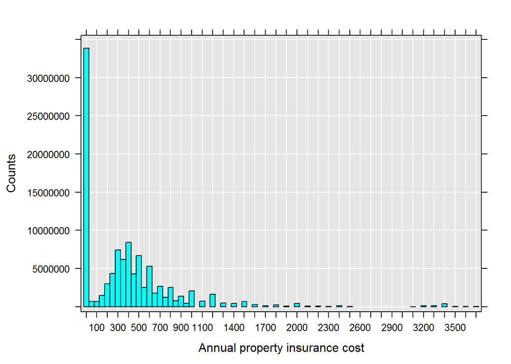

```r
rxHistogram(~propinsr, data = propinFile, pweights = "perwt")
```

Because the histogram shows a “clump” of exact zeros in addition to a distribution of positive values, this appears to be a good match for the Tweedie family with a variance power parameter between 1 and 2,

```r
propinGlm <- rxGlm(propinsr~sex + F(age) + region,
                     pweights = "perwt", data = propinFile,
                       family = rxTweedie(var.power = 1.5), dropFirst = TRUE)
```

[output not shown]

[output cut: 43 more lines]

[output not shown]

Look at the model

```r
summary(propinGlm)
```

```
## Call:
## rxGlm(formula = propinsr ~ sex + F(age) + region, data = propinFile,
##     family = rxTweedie(var.power = 1.5), pweights = "perwt",
##     dropFirst = TRUE)
##
## Generalized Linear Model Results for: propinsr ~ sex + F(age) +
##     region
## Data: propinFile (RxXdfData Data Source)
## File name: C:/DATA/Census
##     Data/Census5PCT2000/CensusPropertyIns.xdf
## Probability weights: perwt
## Dependent variable(s): propinsr
## Total independent variables: 82 (Including number dropped: 4)
## Number of valid observations: 5175270
## Number of missing observations: 0
## Family-link: Tweedie-mu^-0.5
##
## Residual deviance: 3292809839.324 (on 5175192 degrees of freedom)
##
## Coefficients:
##                            Estimate Std. Error t value Pr(>|t|)
## (Intercept)                1.23e-01   5.89e-04  208.96  2.2e-16 ***
## sex=Male                    Dropped    Dropped Dropped  Dropped
## sex=Female                 9.03e-03   3.16e-05  285.31  2.2e-16 ***
## F_age=21                    Dropped    Dropped Dropped  Dropped
## F_age=22                  -9.21e-03   7.52e-04  -12.24  2.2e-16 ***
## F_age=23                  -1.98e-02   6.97e-04  -28.43  2.2e-16 ***
## F_age=24                  -2.86e-02   6.65e-04  -42.95  2.2e-16 ***
## F_age=25                  -3.65e-02   6.43e-04  -56.78  2.2e-16 ***
## F_age=26                  -4.37e-02   6.29e-04  -69.50  2.2e-16 ***
## F_age=27                  -4.89e-02   6.18e-04  -79.16  2.2e-16 ***
## F_age=28                  -5.40e-02   6.10e-04  -88.51  2.2e-16 ***
## F_age=29                  -5.79e-02   6.04e-04  -95.75  2.2e-16 ***
## F_age=30                  -6.06e-02   6.02e-04 -100.72  2.2e-16 ***
## F_age=31                  -6.34e-02   6.00e-04 -105.52  2.2e-16 ***
## F_age=32                  -6.53e-02   5.99e-04 -108.93  2.2e-16 ***
## F_age=33                  -6.72e-02   5.98e-04 -112.49  2.2e-16 ***
## F_age=34                  -6.85e-02   5.96e-04 -114.95  2.2e-16 ***
## F_age=35                  -6.94e-02   5.95e-04 -116.69  2.2e-16 ***
## F_age=36                  -7.09e-02   5.94e-04 -119.34  2.2e-16 ***
```

[output cut: 55 more lines]

```
## region=East North Central  3.55e-03   6.87e-05   51.72  2.2e-16 ***
## region=West North Central  4.20e-04   7.70e-05    5.46  4.8e-08 ***
## region=South Atlantic     -1.23e-03   6.52e-05  -18.82  2.2e-16 ***
## region=East South Central -7.89e-04   7.79e-05  -10.13  2.2e-16 ***
## region=West South Central -5.86e-03   6.73e-05  -87.01  2.2e-16 ***
## region=Mountain            1.82e-03   8.06e-05   22.60  2.2e-16 ***
## region=Pacific            -5.99e-04   6.73e-05   -8.90  2.2e-16 ***
## region=Other                Dropped    Dropped Dropped  Dropped
## ---
## Signif. codes:  0 '***' 0.001 '**' 0.01 '*' 0.05 '.' 0.1 ' ' 1
##
## (Dispersion parameter for Tweedie family taken to be 546.5)
##
## Condition number of final variance-covariance matrix: 5980
## Number of iterations: 8
```

### USE THE MODEL TO MAKE PREDICTIONS FOR 2 REGIONS

Create a prediction data set.

```r
# Create a prediction data set for region 5, all ages, both sexes
varInfo <- rxGetVarInfo(propinFile)
regionLabels <- varInfo$region$levels
region <- factor(rep(5, times=138), levels = 1:10, labels = regionLabels)
age <- c(21:89, 21:89)
sex <- factor(c(rep(1, times=69), rep(2, times=69)), levels = 1:2, labels = c("Male", "Female"))
predData <- data.frame(age, sex, region)
#
# Create a prediction data set for region 2, all ages, both sexes
predData2 <- predData
predData2$region <-factor(rep(2, times=138), levels = 1:10,
labels = varInfo$region$levels)
#
# Combine data sets and compute predictions
predData <- rbind(predData, predData2)
head(predData)
```

```
##   age  sex         region
## 1  21 Male South Atlantic
## 2  22 Male South Atlantic
## 3  23 Male South Atlantic
## 4  24 Male South Atlantic
## 5  25 Male South Atlantic
## 6  26 Male South Atlantic
```

```r
tail(predData)
```

```
##     age    sex          region
## 271  84 Female Middle Atlantic
## 272  85 Female Middle Atlantic
## 273  86 Female Middle Atlantic
## 274  87 Female Middle Atlantic
## 275  88 Female Middle Atlantic
## 276  89 Female Middle Atlantic
```

#### Use model to predict results on prediction data set

```r
outData <- rxPredict(propinGlm, data = predData)
```

```
## Rows Read: 276, Total Rows Processed: 276, Total Chunk Time: 0.002 seconds
```

### Plot the predictions

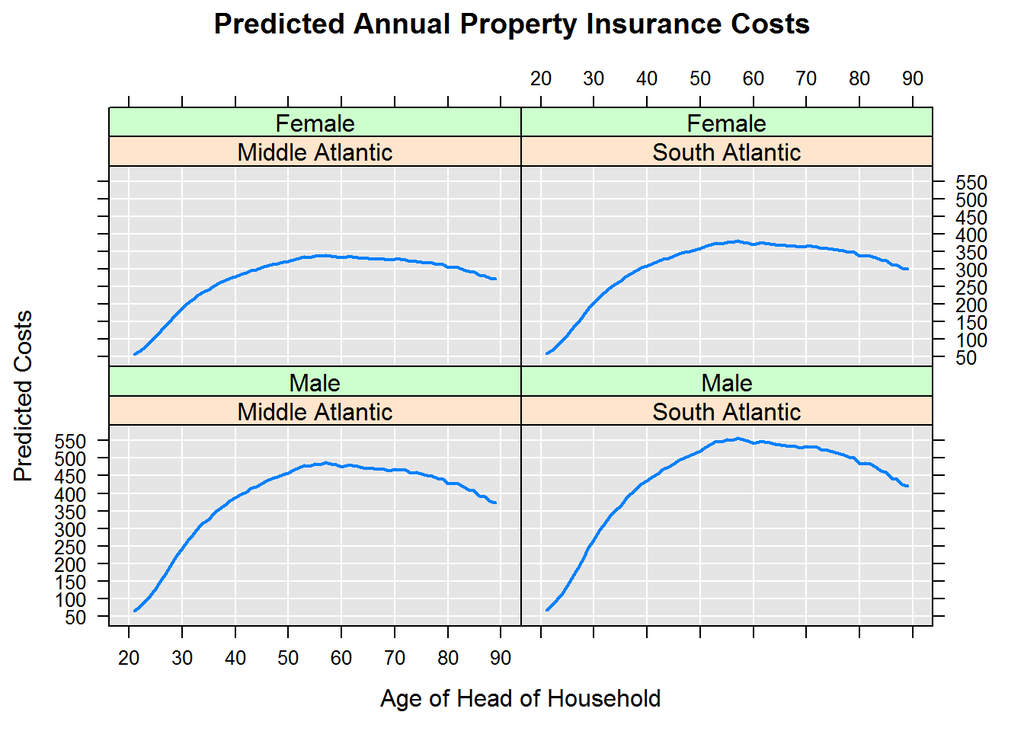

```r
predData$predicted <- outData$propinsr_Pred
rxLinePlot( predicted ~age|region+sex, data = predData,
title = "Predicted Annual Property Insurance Costs",
xTitle = "Age of Head of Household",
yTitle = "Predicted Costs")
```